# Atividade (exemplo de relatório) Seleção Estágio TCU

Augusto Cesar Ribeiro Nunes

20 de março de 2015

# Introdução / Objetivo

# Metodologia de Amostragem

# Descrição Base de Dados

Composta pelo conjunto de 852 observações das 7 variáveis a seguir:

- **id**: Número do Questionário
- **sexo**: Gênero do respondente, com duas categorias:
  - *Masculino*
  - *Feminino*
- **idade**: Idade do respondente, em anos completos quando da resposta ao questionário (????)
- **localdomicilio**: Local do Domicílio (quanto à classificação da área que ocupa majoritariamente?), com duas categorias:
  - *Urbano*
  - *Rural*
- **especiedomicilio**: Espécie do domicílio, com quatro categorias:
  - *Particular permanente*
  - *Particular improvisado*
  - *Alugado*
  - *Coletivo*
- **qtdcomodos**: Número de cômodos do domicílio
- **pavimentacao**: Se existe calçamento/pavimentação em frente ao domicílio, com três categorias:
  - *Total*
  - *Parcial*
  - *Não existe*

Estrutura da Base de Dados

```
## 'data.frame':    852 obs. of  7 variables:
##  $ id              : int  1 2 3 4 5 6 7 8 9 10 ...
##  $ sexo            : int  2 1 2 2 1 2 2 1 1 2 ...
##  $ idade           : int  75 26 48 73 58 19 21 47 67 71 ...
##  $ localdomicilio  : int  1 1 2 1 2 1 2 1 1 1 ...
##  $ especiedomicilio: int  4 3 4 3 3 3 4 3 3 4 ...
##  $ qtdcomodos      : int  3 3 1 3 4 1 3 3 4 4 ...
##  $ pavimentacao    : int  2 1 2 3 1 3 1 1 2 3 ...
```

# Descrição dos respondentes na amostra

## Quanto ao gênero

```
## sexo
##       n missing  unique
##     852       0       2
##
## Masculino (432, 51%), Feminino (420, 49%)
```

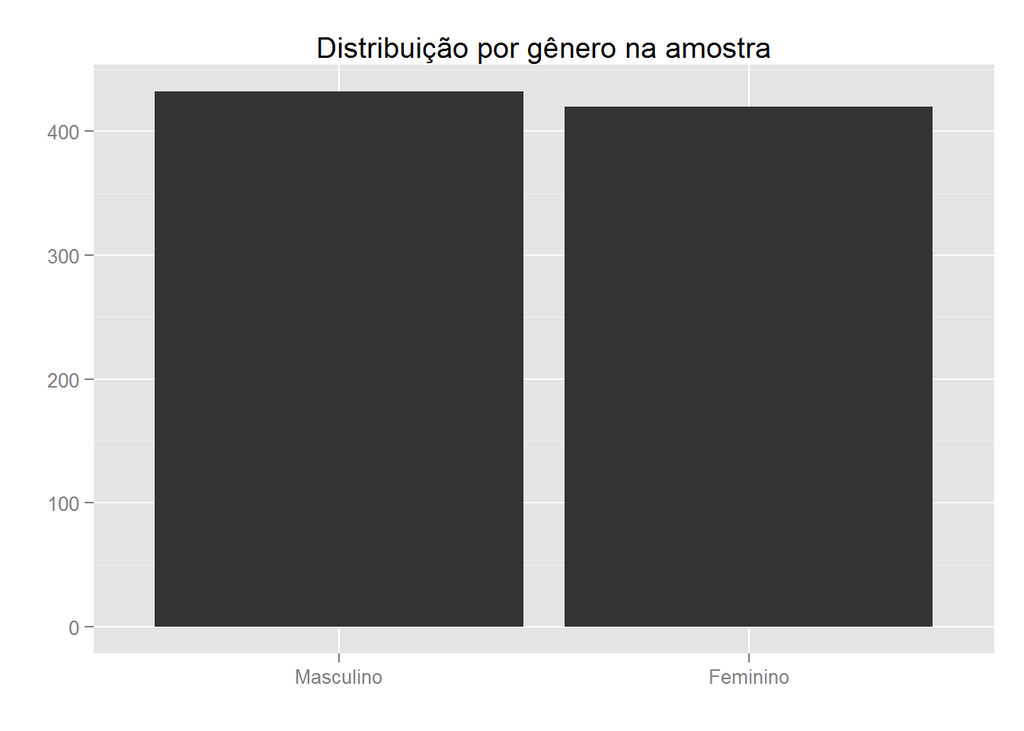

A leve discrepância entre o percentual de homens e mulheres e a relação observada pelo Censo Demográfico, mas nada considerável.

## Quanto à idade

```
## Descrição por idade
##       n missing  unique    Info    Mean     .05     .10     .25     .50
##     852       0      63       1   49.79   21.00   25.00   33.00   50.00
##     .75     .90     .95
##   66.25   75.00   78.00
##
## lowest : 19 20 21 22 23, highest: 77 78 79 80 81
```

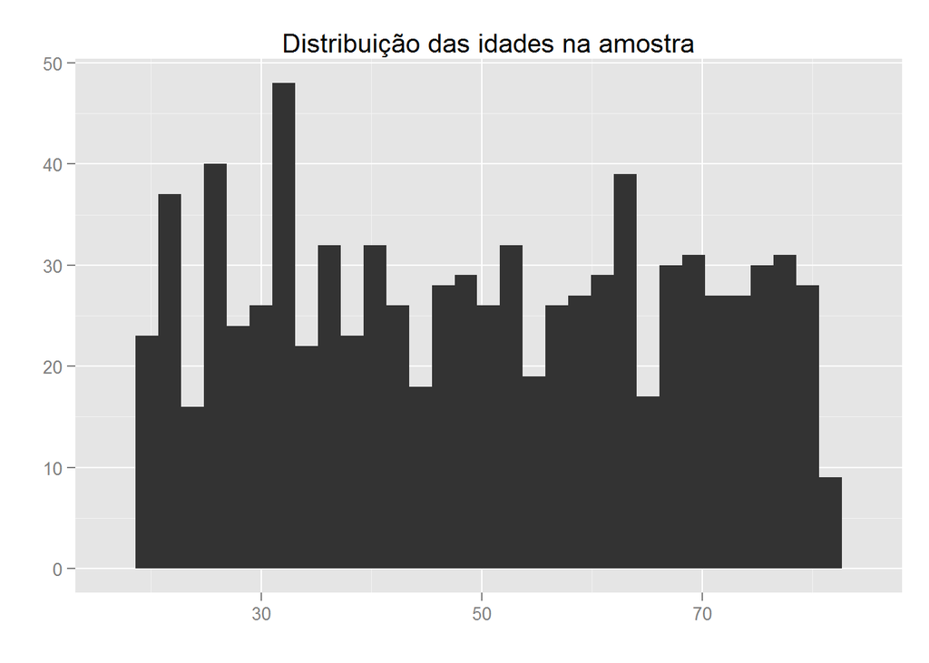

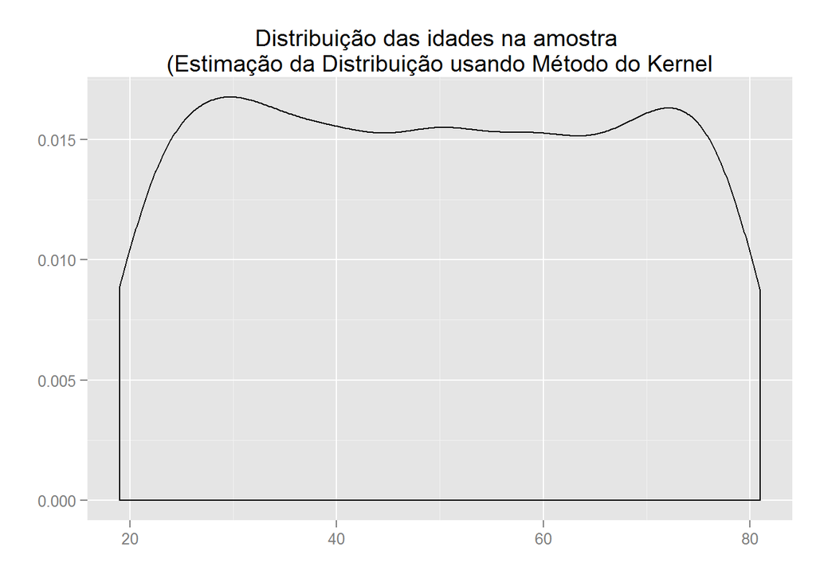

Mediana alta (50 anos), pode ser explicada se essa amostra apresentar um número considerável de proprietários de imóveis e/ou moradores de regiões ou bairros cuja população seja constituída de mais velhos (exemplo de RAs do DF como Lago Sul e Lago Norte).

A amplitude de idades também é grande, 62 anos de idade.

## Quanto ao local de domicílio

```
## Descrição por local do domicílio
##       n missing  unique
##     852       0       2
##
## Urbano (449, 53%), Rural (403, 47%)
```

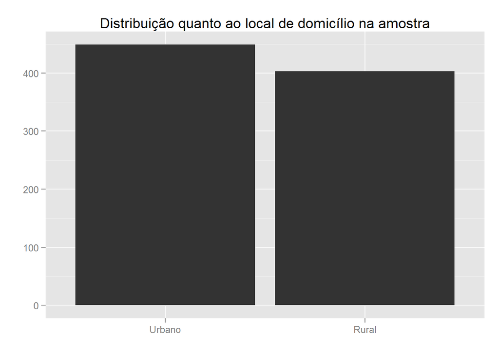

## Quanto à espécie do domicílio

```
## Descrição por espécie do domicílio
##       n missing  unique
##     852       0       4
##
## Particular permanente (194, 23%)
## Particular improvisado (217, 25%)
## Alugado (197, 23%), Coletivo (244, 29%)
```

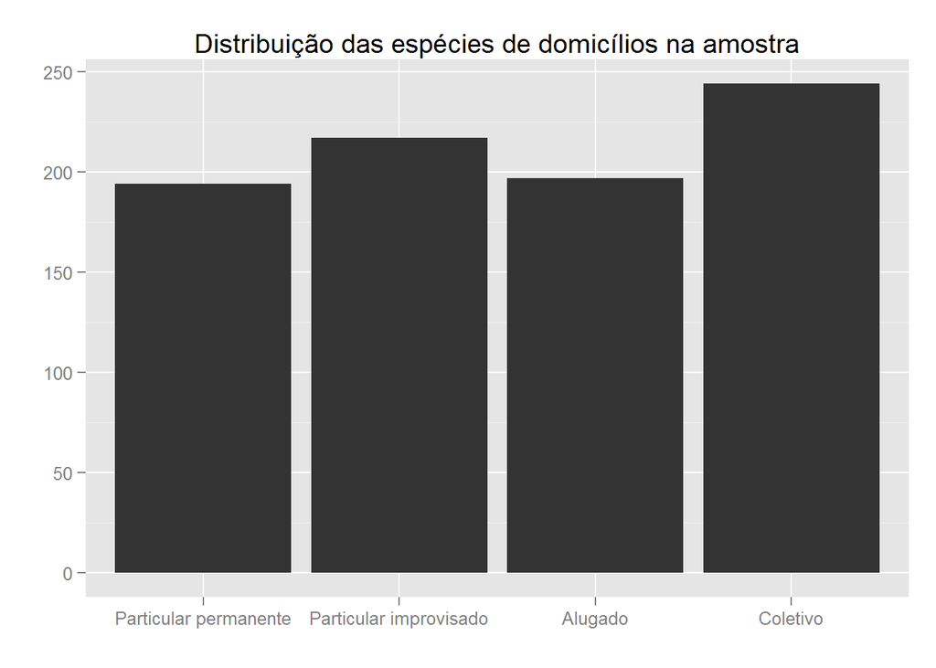

## Quanto à quantidade de cômodos

```
## Descrição por quantidade de cômodos
##       n missing  unique    Info    Mean
##     852       0       4    0.94   2.526
##
## 1 (212, 25%), 2 (199, 23%), 3 (222, 26%), 4 (219, 26%)
```

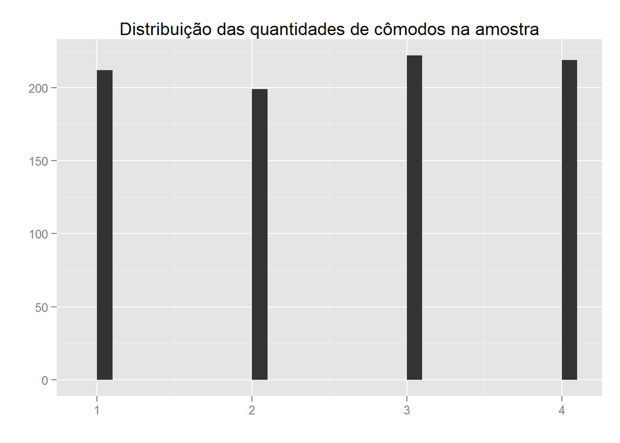

## Quanto à pavimentação

```
## pavimentacao
##       n missing  unique
##     852       0       3
##
## Total (280, 33%), Parcial (293, 34%)
## Não existe (279, 33%)
```

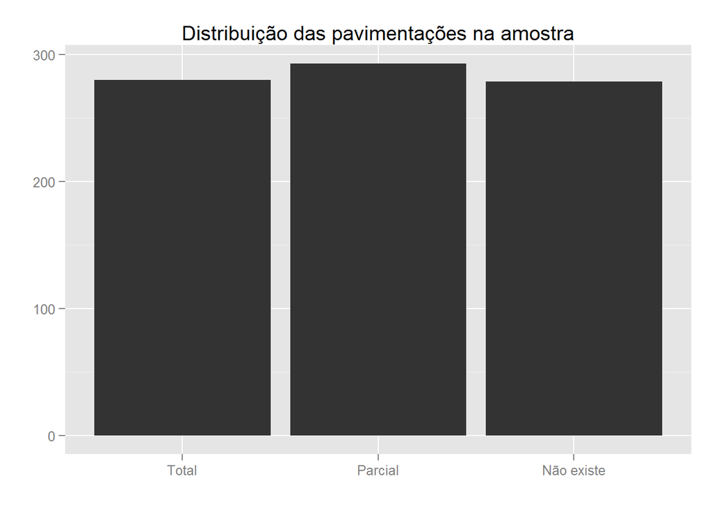

# Análise de relação entre gênero e demais variáveis

## Gênero x Idade

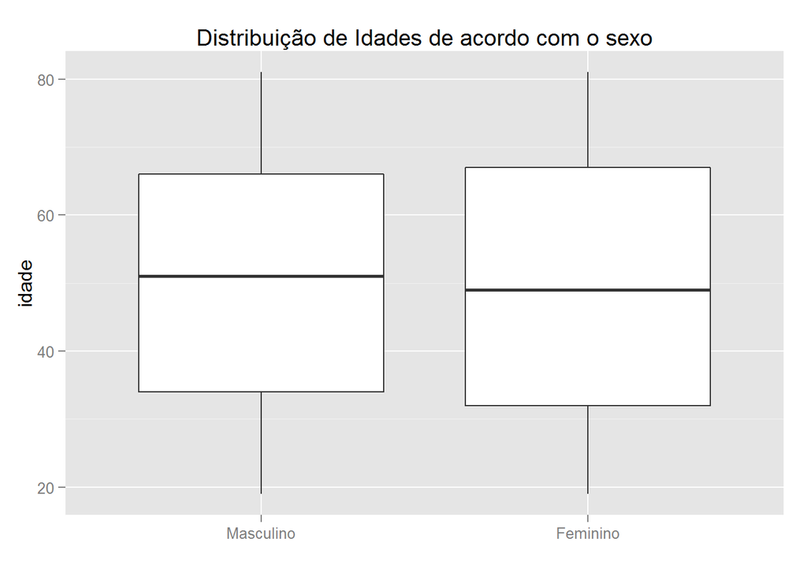

Média de idade dos homens superior à das mulheres, mas não tão marcadamente.

## Gênero x Local do Domicílio

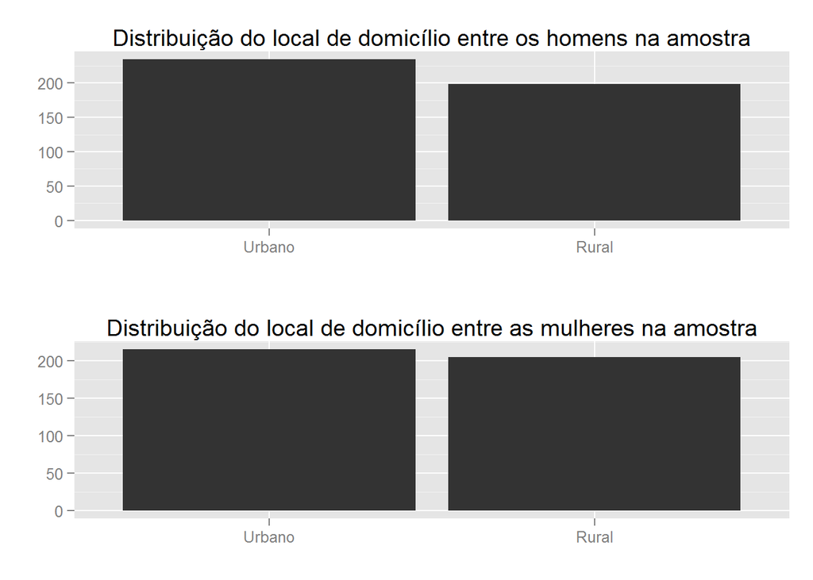

Nenhuma diferença marcante entre o local de domicílios de homens e mulheres respondentes na amostra.

## Gênero x Espécie do Domicílio

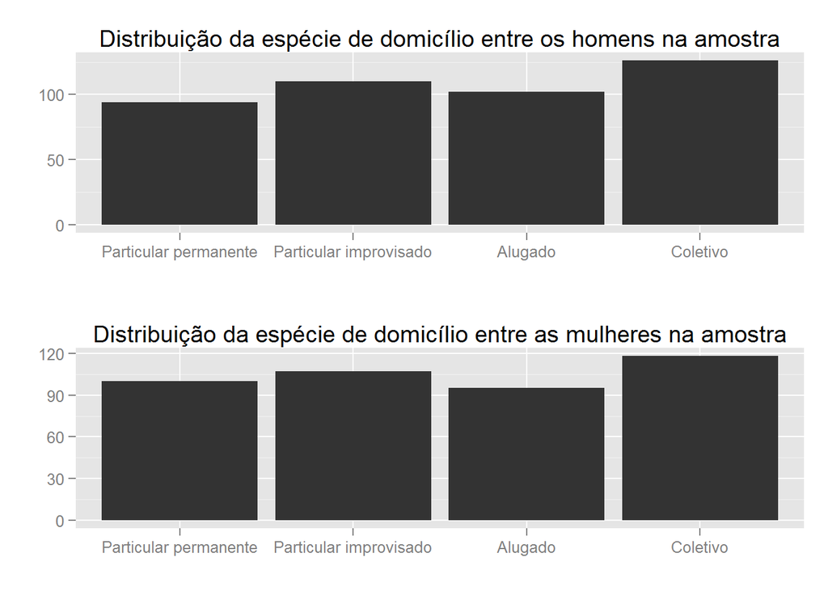

A distribuição de domicílios também não apresenta nada digno de nota quando é discriminada pelo gênero do respondente.

## Gênero x Quantidade de Cômodos

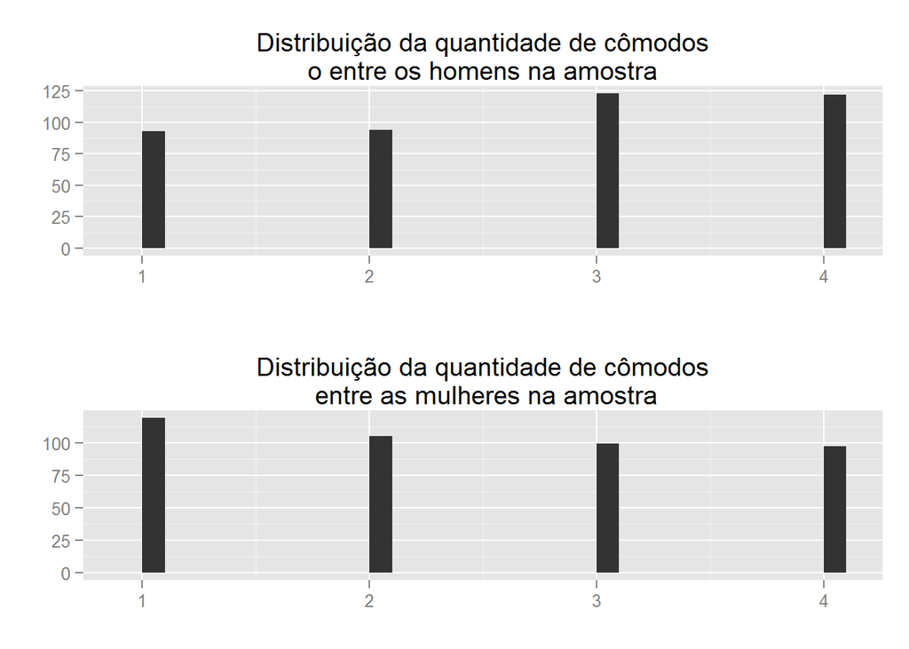

Aqui sim uma diferença mais marcante, uma proprorção maior de mulheres vive em domicílios com menos cômodos, como se uma distribuição fosse praticamente anti-simétrica à outra.

## Gênero x Pavimentação

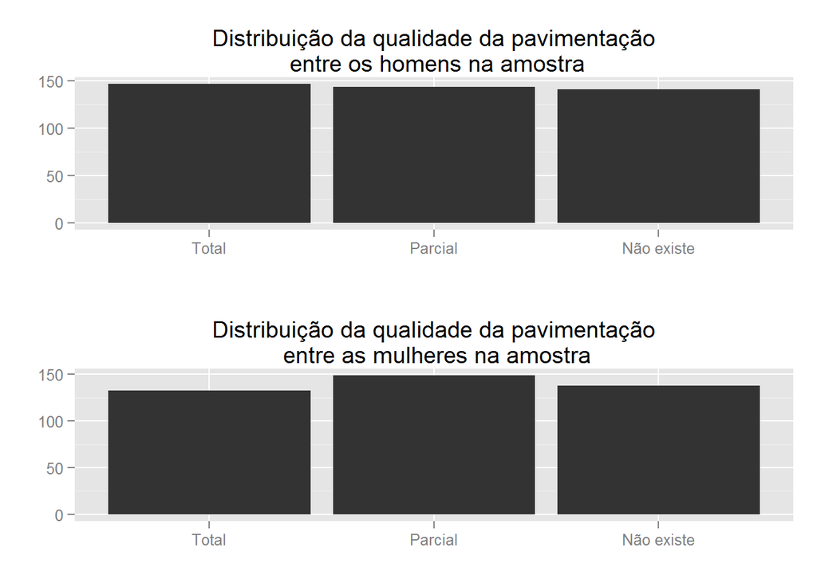

Mais uma vez um déficit qualitativo entre os gêneros. Menos mulheres respodentes vivem em domicílios com pavimentação total.

# Análise da relação entre a idade e as demais variáveis

Para enriquecer a análise, usaremos classes de idade da seguinte forma

[output not shown]

## Idade x Local do Domicílio

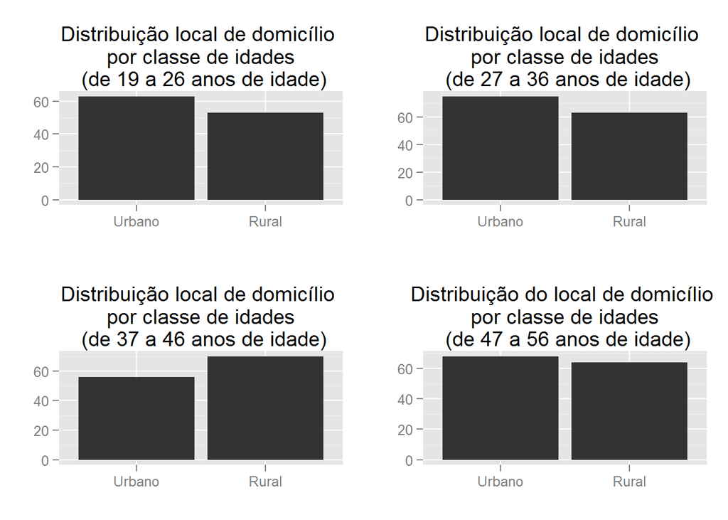

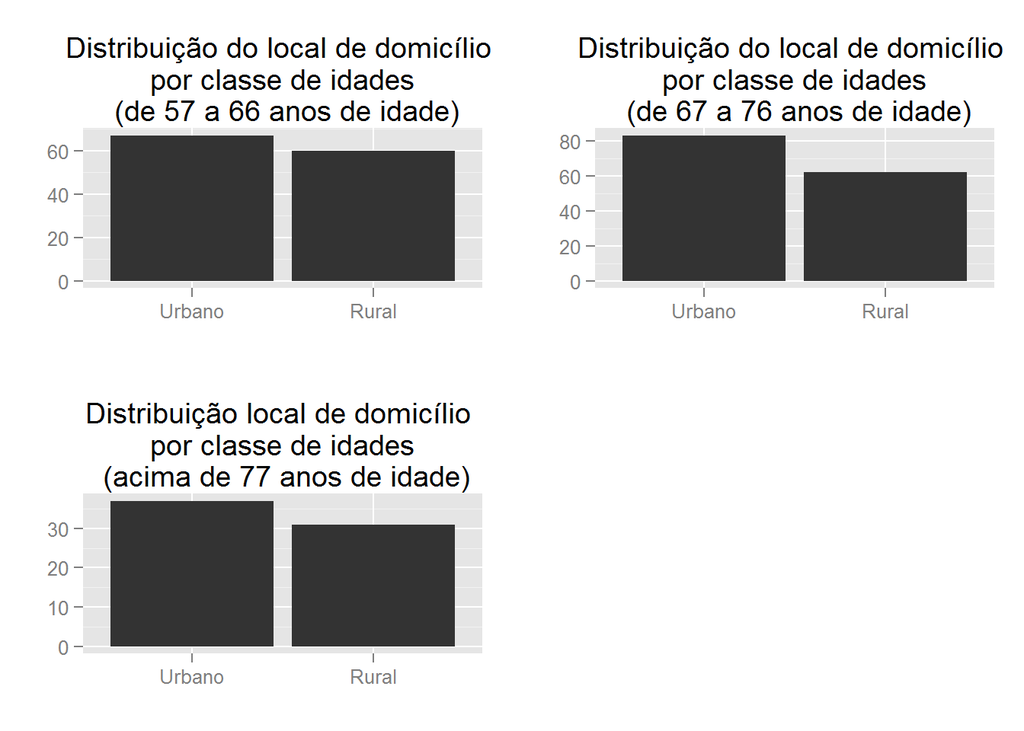

Não há nenhum comportamento sistemático marcante de discriminação do local de moradia por classe de idade, exceto pela classe de 37 a 46 anos de idade, que tem menos pessoas morando em local urbano do que em local rural - ao contrário do que ocorre em todas as outras classes. Pode ser uma mera casualidade amostral, e muito provavelmente é, já que, como foi dito, este cenário não é observado em nenhuma outra classe de idade.

## Idade x Espécie do Domicílio

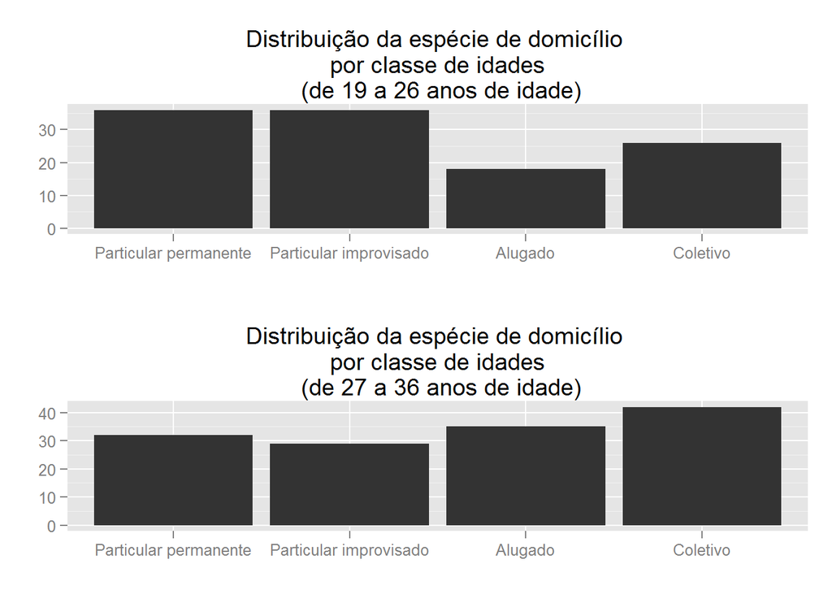

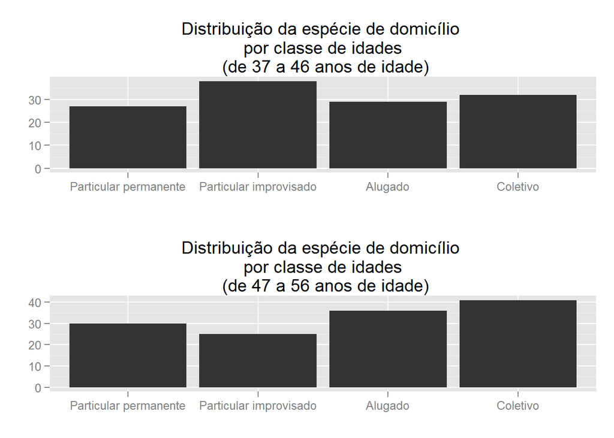

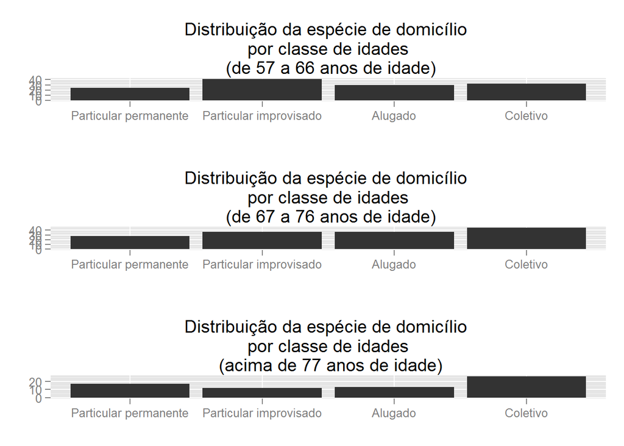

Apenas olhando os gráficos já nota-se uma sugestão de tendência nos indivíduos dessa amostra, ao passar dos anos, as pessoas vão migrando de domicílios que se enquadram nas categorias Particular Permanente/Improvisado (de 19 a 26 anos de idade), para Alugado/Coletivo (27 a 36 anos), de volta para domicílios particulares (37 a 46), e no fim da vida, para domicílios Coletivos novamente. É claro que esta é apenas uma especulação dada a estatística descritiva, deveria ser feito um estudo de coortes (longitudinal) para chegar a resultados mais concretos. Mas uma boa indicação. No entanto, o teste $\chi^2$ nos dá o seguinte resultado:

```r
  chisq.test(idade,especiedomicilio)
```

```
##
##  Pearson's Chi-squared test
##
## data:  idade and especiedomicilio
## X-squared = 217.68, df = 186, p-value = 0.05573
```

## Idade x Quantidade de Cômodos

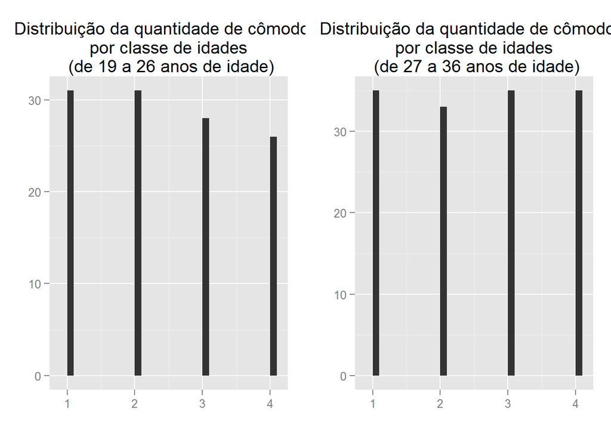

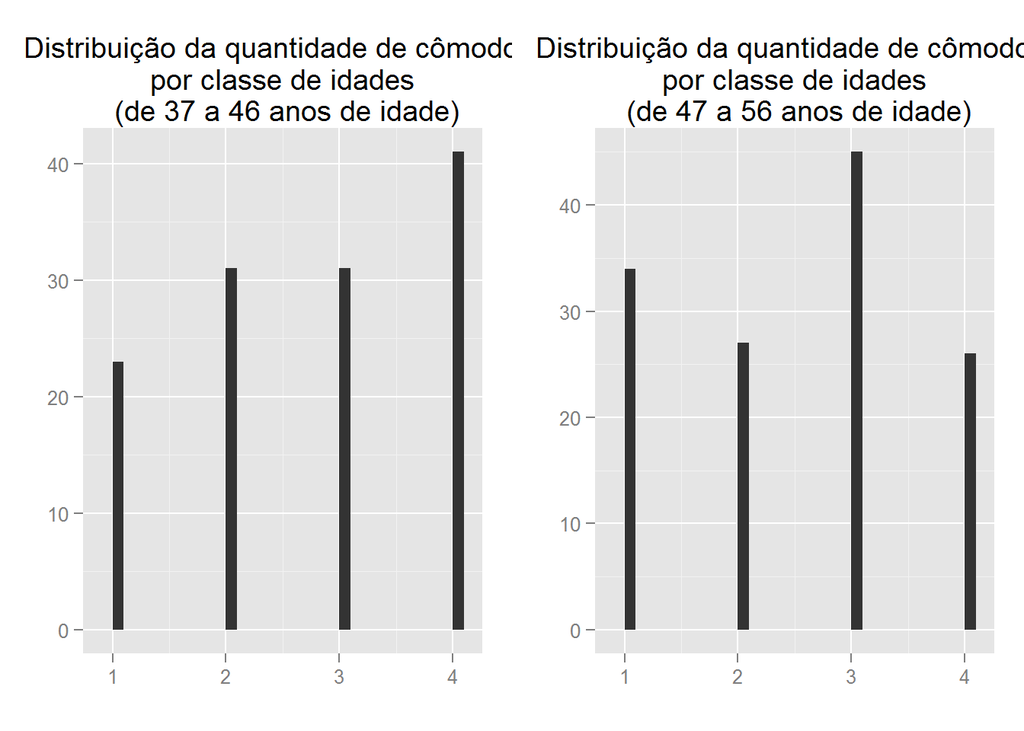

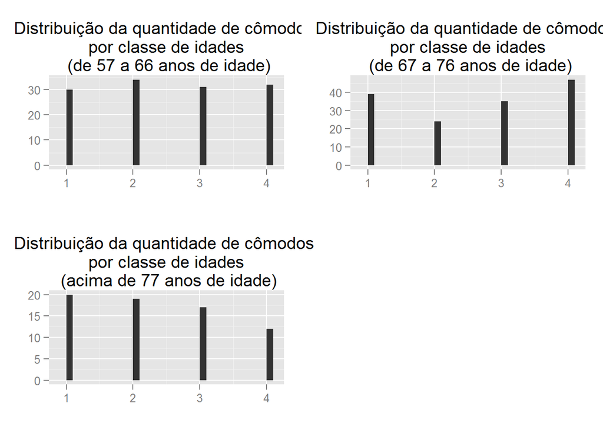

Aqui, a sugestão de tendência é que mais jovens e mais idosos tendem a viver em domicílios com número menor de cômodos. Aqueles que pertencem as classes de idade intermediária, talvez pelo fato de terem estabelecido família - e em particular, terem filhos - precisam de domicílos maiores. Utilizando mais uma vez um teste de hipóteses não-paramétrico - desta vez a *Correlação Produto - Momento de Pearson* - desta vez concluimos que a correlação sugerida pelos gráficos não se sustenta na amostra.

```r
  cor.test(qtdcomodos,idade)
```

```
##
##  Pearson's product-moment correlation
##
## data:  qtdcomodos and idade
## t = 0.1669, df = 850, p-value = 0.8675
## alternative hypothesis: true correlation is not equal to 0
## 95 percent confidence interval:
##  -0.06146291  0.07286174
## sample estimates:
##         cor
## 0.005725242
```

## Idade x Pavimentação

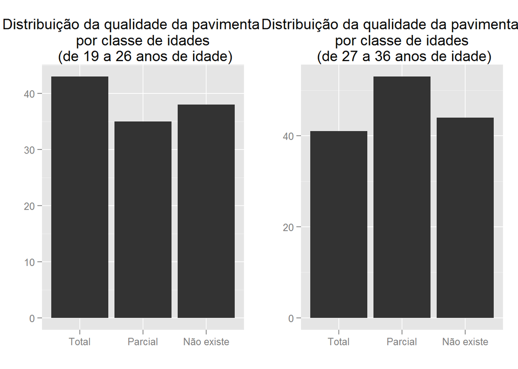

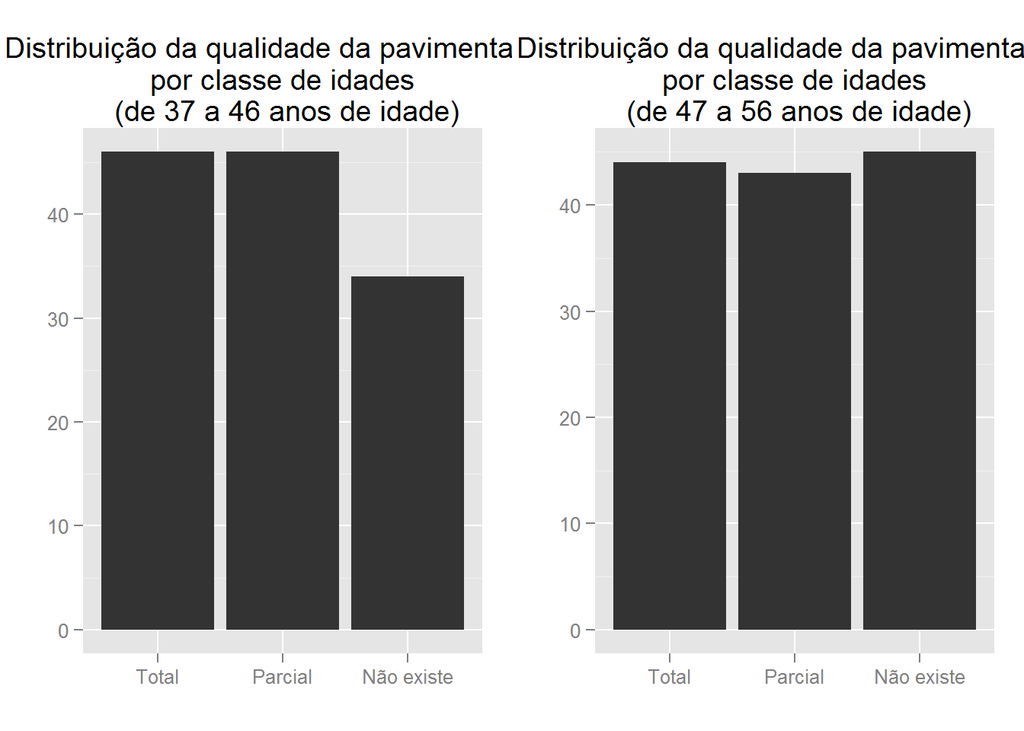

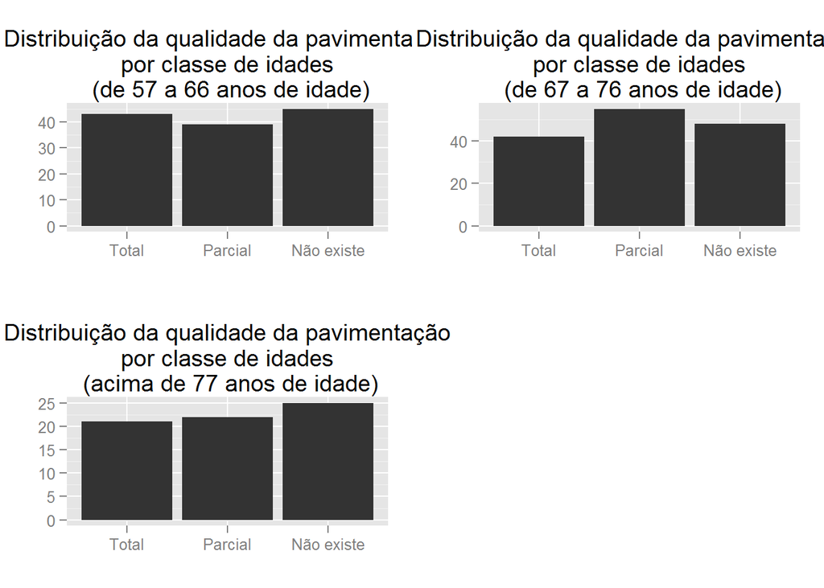

Utilizando novamente o teste $\chi^2$, concluímos que não há significância considerável na relação entre a idade e o tipo de pavimentação.

```r
  chisq.test(idade, pavimentacao)
```

```
##
##  Pearson's Chi-squared test
##
## data:  idade and pavimentacao
## X-squared = 125.0989, df = 124, p-value = 0.4555
```

# Análises de Regressão

## A Idade influencia na espécie e local do domicílio?

```
##
## Call:
## lm(formula = idade ~ localdomicilio + especiedomicilio)
##
## Residuals:
##     Min      1Q  Median      3Q     Max
## -32.700 -16.151  -0.475  16.137  33.168
##
## Coefficients:
##                                        Estimate Std. Error t value
## (Intercept)                             48.5553     1.4759  32.899
## localdomicilioRural                     -0.7228     1.2630  -0.572
## especiedomicilioParticular improvisado   0.5628     1.8146   0.310
## especiedomicilioAlugado                  2.3181     1.8589   1.247
## especiedomicilioColetivo                 3.1451     1.7701   1.777
##                                        Pr(>|t|)
## (Intercept)                              <2e-16 ***
## localdomicilioRural                       0.567
## especiedomicilioParticular improvisado    0.757
## especiedomicilioAlugado                   0.213
## especiedomicilioColetivo                  0.076 .
## ---
## Signif. codes:  0 '***' 0.001 '**' 0.01 '*' 0.05 '.' 0.1 ' ' 1
##
## Residual standard error: 18.36 on 847 degrees of freedom
## Multiple R-squared:  0.005505,   Adjusted R-squared:  0.0008081
## F-statistic: 1.172 on 4 and 847 DF,  p-value: 0.3216
```

A única relação com discreta significância é entre a Idade e o Domicílio Coletivo.

## A Idade influencia no tipo de pavimentação e no número de cômodos?

```
##
## Call:
## lm(formula = idade ~ pavimentacao + qtdcomodos)
##
## Residuals:
##     Min      1Q  Median      3Q     Max
## -31.492 -16.516  -0.026  16.436  32.205
##
## Coefficients:
##                        Estimate Std. Error t value Pr(>|t|)
## (Intercept)            48.60262    1.79418  27.089   <2e-16 ***
## pavimentacaoParcial     1.23071    1.53654   0.801    0.423
## pavimentacaoNão existe  1.60025    1.55529   1.029    0.304
## qtdcomodos              0.09642    0.56095   0.172    0.864
## ---
## Signif. codes:  0 '***' 0.001 '**' 0.01 '*' 0.05 '.' 0.1 ' ' 1
##
## Residual standard error: 18.39 on 848 degrees of freedom
## Multiple R-squared:  0.001404,   Adjusted R-squared:  -0.002128
## F-statistic: 0.3976 on 3 and 848 DF,  p-value: 0.7548
```

O resultado da regressão nos diz que não há significância no relacionamento entre estas três variáveis.